# Touched objects analysis

Luise Rauer

23 7 2022

### Summary & questions

- Some unusual results from DADA2 (see “processing” markdown)
- Strong batch effect
- “Gate lion” and “Tendaguru” appear as objects in both batches, might be an opportunity to compare samples between batches?
- Major problem: distinction between skin bacteria, contaminants/controls, and the surface microbiome of inanimate objects - what kind of microbiome are we expecting in untouched objects?
- What are BS negative controls?

## Analysis

### Setting up the workspace

```r
# ------------------------------------------------------------------------------
# Set up the workspace
# ------------------------------------------------------------------------------

# Load required packages
library(tidyverse)
library(metacal)

# Set input directory
path <- "C:/Users/rauerlui/PhD/Sonstiges/2022.05 Museum touched objects microbiome/"
# Path for output
path_output <- paste0(path, "Output/")

# Define plot colours
theme_colours <- c("#4669A5", "#e65d1e", "#5dc9cf", "#ffda0a", "#ba002b",
                   "#6ed957", "#ffbdc7", "#c97b00", "#fff79c", "#277527",
                   "#ff7891", "#c6f279", "#3f1163", "#f0b400", "#729ce8",
                   "#8F1870", "#e3cb6f", "#248c8c", "#e61e1e", "#98d8fe",
                   "#a84c1b", "#D68CCC", "#065e5e", "#ff9c75", "#9DBD32",
                   "#B957A3", sample(rainbow(250)))
```

### Load and process ASV table

```r
# Load processed sequencing data
load(paste0(path_output, "/DADA2_main_objects.RData"), verbose = TRUE)
```

```
## Loading objects:
##   ASV_ID
##   sample.names
##   seqtab.filt
##   seqtab.nochim
##   taxa_RDP
##   taxid_rdp
##   taxid_silva
##   track
```

```r
# Merge ASV table with RDP taxonomy
seqtab.final <- merge(data.frame(OTU_ID = ASV_ID, t(seqtab.filt),
                                 check.names = FALSE),
                      taxa_RDP, by = 0, all = TRUE)
colnames(seqtab.final)[colnames(seqtab.final) == "Row.names"] <- "Sequence"

# Percent of sequences without genus level annotation
sum(is.na(seqtab.final$Genus))/nrow(seqtab.final) # 16.7 %
```

```
## [1] 0.1674195
```

```r
# Percent of reads without genus level annotation
sum(seqtab.final[is.na(seqtab.final$Genus), sample.names])/
  sum(seqtab.final[, sample.names]) # 13.7%
```

```
## [1] 0.1370316
```

```r
# Add genera from IdTaxa
seqtab.final <- merge(seqtab.final, taxid_rdp[, "genus"], by.x = "Sequence",
                      by.y = 0)
colnames(seqtab.final)[colnames(seqtab.final) == "y"] <- "IdTaxa_RDP"
seqtab.final <- merge(seqtab.final, taxid_silva[, "genus"], by.x = "Sequence",
                      by.y = 0)
colnames(seqtab.final)[colnames(seqtab.final) == "y"] <- "IdTaxa_Silva"
seqtab.final["Mixed_genus"] <- seqtab.final["Genus"]
seqtab.final$Mixed_genus[is.na(seqtab.final$Mixed_genus)] <-
  seqtab.final$IdTaxa_RDP[is.na(seqtab.final$Mixed_genus)]
seqtab.final$Mixed_genus[is.na(seqtab.final$Mixed_genus)] <-
  seqtab.final$IdTaxa_Silva[is.na(seqtab.final$Mixed_genus)]

# Percent of sequences without genus level annotation
sum(is.na(seqtab.final$Mixed_genus))/nrow(seqtab.final) # 12.9 %
```

```
## [1] 0.1293285
```

```r
# Percent of reads without genus level annotation
sum(seqtab.final[is.na(seqtab.final$Mixed_genus), sample.names])/
  sum(seqtab.final[, sample.names]) # 10.1 %
```

```
## [1] 0.1018045
```

```r
# Sort ASV table by ASV_ID
seqtab.final <- seqtab.final[order(seqtab.final$OTU_ID), ]
row.names(seqtab.final) <- NULL
```

### Load and process ASV table

```r
# Read metainformation
metadata <- readxl::read_excel("C:/Users/rauerlui/PhD/Sonstiges/2022.05 Museum touched objects microbiome/sample_sheet_data_science.xlsx", sheet = "Tabelle1")
metadata <- as.data.frame(metadata)
colnames(metadata) <- gsub(" ", "_", colnames(metadata))
str(metadata)
```

```
## 'data.frame':    126 obs. of  27 variables:
##  $ sample_id              : chr  "L1" "L2" "L3" "L4" ...
##  $ Sequencing_run         : chr  "first" "first" "first" "first" ...
##  $ Sampling_date          : POSIXct, format: "2020-10-08" "2020-10-08" ...
##  $ Sampling_duration_(min): num  1 1 1 1 1 1 1 1 1 1 ...
##  $ area                   : chr  "small" "small" "small" "small" ...
##  $ Sampling_number        : chr  "1.0" "2.0" "3.0" "4.0" ...
##  $ DZMZ_Lfd_Nummer        : num  NA NA NA NA NA NA NA NA NA NA ...
##  $ DSMZ_Probe             : chr  "L_1" "L_2" "L_3" "L_4" ...
##  $ DSMZ_Barcode           : num  29 1 30 2 31 3 32 4 33 5 ...
##  $ DSMZ_Index             : num  1 1 1 1 1 1 1 1 1 1 ...
##  $ Object_number_SPK      : chr  "1.0" "1.0" "1.0" "1.0" ...
##  $ Object_number_MfN      : num  NA NA NA NA NA NA NA NA NA NA ...
##  $ Spot_number            : num  1 1 2 2 3 3 4 4 5 5 ...
##  $ Sample                 : num  1 2 1 2 1 2 1 2 1 2 ...
##  $ Institution            : chr  "SPK" "SPK" "SPK" "SPK" ...
##  $ Collection             : chr  "VAM" "VAM" "VAM" "VAM" ...
##  $ Type_of_room           : chr  "exhibition" "exhibition" "exhibition" "exhibition" ...
##  $ Object                 : chr  "Gate Lion right Sam'al" "Gate Lion right Sam'al" "Gate Lion right Sam'al" "Gate Lion right Sam'al" ...
##  $ Material               : chr  "Stone" "Stone" "Stone" "Stone" ...
##  $ Stone_type             : chr  "Basalt/Dolerite" "Basalt/Dolerite" "Basalt/Dolerite" "Basalt/Dolerite" ...
##  $ Color                  : chr  NA NA NA NA ...
##  $ Inv._number            : chr  "VA 2718" "VA 2718" "VA 2718" "VA 2718" ...
##  $ Spot                   : chr  "tooth" "tooth" "back" "back" ...
##  $ Height                 : chr  "1.6" "1.6" "1.6" "1.6" ...
##  $ Touched                : chr  "x" "x" NA NA ...
##  $ Comments               : chr  "touched" "touched" "untouched" "untouched" ...
##  $ Comments_2             : chr  NA NA NA NA ...
```

```r
# Match sample names in ASV table with metainformation
metadata$sample_id %in% sample.names
```

```
##   [1] FALSE FALSE FALSE FALSE FALSE FALSE FALSE FALSE FALSE FALSE FALSE FALSE
##  [13] FALSE FALSE FALSE FALSE FALSE FALSE FALSE FALSE FALSE FALSE FALSE FALSE
##  [25] FALSE FALSE FALSE FALSE FALSE FALSE FALSE FALSE FALSE FALSE FALSE FALSE
##  [37] FALSE FALSE FALSE FALSE FALSE FALSE FALSE FALSE FALSE FALSE FALSE FALSE
##  [49] FALSE FALSE FALSE FALSE FALSE FALSE FALSE FALSE FALSE FALSE  TRUE  TRUE
##  [61]  TRUE  TRUE  TRUE  TRUE  TRUE  TRUE  TRUE  TRUE  TRUE  TRUE  TRUE  TRUE
##  [73]  TRUE  TRUE  TRUE  TRUE  TRUE  TRUE  TRUE  TRUE  TRUE  TRUE  TRUE  TRUE
##  [85]  TRUE  TRUE  TRUE  TRUE  TRUE  TRUE  TRUE  TRUE  TRUE  TRUE  TRUE FALSE
##  [97] FALSE FALSE FALSE FALSE FALSE FALSE FALSE FALSE FALSE FALSE FALSE FALSE
## [109] FALSE FALSE FALSE FALSE  TRUE  TRUE FALSE FALSE  TRUE  TRUE  TRUE FALSE
## [121] FALSE FALSE FALSE FALSE FALSE  TRUE
```

```r
setdiff(sample.names, metadata$sample_id)
```

```
##  [1] "L_1"                "L_10"               "L_11"
##  [4] "L_12"               "L_13"               "L_14"
##  [7] "L_15"               "L_16"               "L_17"
## [10] "L_18"               "L_19"               "L_2"
## [13] "L_20"               "L_21"               "L_22"
## [16] "L_23"               "L_24"               "L_25"
## [19] "L_26"               "L_27"               "L_28"
## [22] "L_29"               "L_3"                "L_30"
## [25] "L_31"               "L_32"               "L_33"
## [28] "L_34"               "L_35"               "L_36"
## [31] "L_37"               "L_38"               "L_39"
## [34] "L_4"                "L_40"               "L_41"
## [37] "L_42"               "L_43"               "L_45"
## [40] "L_46"               "L_47"               "L_48"
## [43] "L_49"               "L_5"                "L_50"
## [46] "L_51"               "L_52"               "L_53"
## [49] "L_54"               "L_55"               "L_56"
## [52] "L_58"               "L_59"               "L_6"
## [55] "L_60"               "L_7"                "L_8"
## [58] "L_9"                "L_NC_BS1"           "L_NC_BS2"
## [61] "L_NC_BS3"           "L_NC_Kit_1"         "L_NC_Kit_3"
## [64] "L_NC_Kit2"          "2MfN_1"             "2MfN_10"
## [67] "2MfN_11"            "2MfN_12"            "2MfN_13"
## [70] "2MfN_14"            "2MfN_15"            "2MfN_16"
## [73] "2MfN_17"            "2MfN_18"            "2MfN_2"
## [76] "2MfN_3"             "2MfN_4"             "2MfN_5"
## [79] "2MfN_6-2NC Kit III" "2MfN_7"             "2MfN_8"
## [82] "2MfN_9"             "NC_PCR2"
```

```r
setdiff(metadata$sample_id, sample.names)
```

```
##  [1] "L1"               "L2"               "L3"               "L4"
##  [5] "L5"               "L6"               "L7"               "L8"
##  [9] "L9"               "L10"              "L11"              "L12"
## [13] "L13"              "L14"              "L15"              "L16"
## [17] "L17"              "L18"              "L19"              "L20"
## [21] "L21"              "L22"              "L23"              "L24"
## [25] "L25"              "L26"              "L27"              "L28"
## [29] "L29"              "L30"              "L31"              "L32"
## [33] "L33"              "L34"              "L35"              "L36"
## [37] "L37"              "L38"              "L39"              "L40"
## [41] "L41"              "L42"              "L43"              "L45"
## [45] "L46"              "L47"              "L48"              "L49"
## [49] "L50"              "L51"              "L52"              "L53"
## [53] "L54"              "L55"              "L56"              "L58"
## [57] "L59"              "L60"              "MfN1"             "MfN2"
## [61] "MfN3"             "MfN4"             "MfN5"             "MfN7"
## [65] "MfN8"             "MfN9"             "MfN10"            "MfN11"
## [69] "MfN12"            "MfN13"            "MfN14"            "MfN15"
## [73] "MfN16"            "MfN17"            "MfN18"            "MfN6-2NC Kit III"
## [77] "NCPCR2"           "LNC BS1"          "LNC BS2"          "LNC BS3"
## [81] "LNC Kit 1"        "LNC Kit 2"        "LNC Kit 3"
```

```r
# Add underscore in batch1
metadata$sample_id <- gsub("L(?=[0-9])", "L_", metadata$sample_id, perl = TRUE)
# Add underscore in MfN samples
metadata$sample_id <- gsub("MfN", "2MfN_", metadata$sample_id)
# Replace specific names
metadata$sample_id[metadata$sample_id == "NCPCR2"] <- "NC_PCR2"
metadata$sample_id <- gsub("LNC BS", "L_NC_BS", metadata$sample_id)
metadata$sample_id <- gsub("LNC Kit ", "L_NC_Kit_", metadata$sample_id)
metadata$sample_id[metadata$sample_id == "L_NC_Kit_2"] <- "L_NC_Kit2"
# Check again
all(sample.names %in% metadata$sample_id)
```

```
## [1] TRUE
```

```r
# Order metainformation
metadata <- metadata[match(sample.names, metadata$sample_id), ]
row.names(metadata) <- metadata$sample_id

# Touch data
metadata$Touched[is.na(metadata$Touched)] <- "0"

# Add complete sample and batch information to metafile
metadata["Sample_type"] <- case_when(
  grepl("PCR", metadata$sample_id) ~ "NEG_PCR",
  grepl("Kit", metadata$sample_id) ~ "NEG_Kit",
  grepl("swab", metadata$sample_id) ~ "NEG_Swab",
  grepl("BS", metadata$sample_id) ~ "NEG_BS",
  metadata$Material == "Air" ~ "NEG_Air",
  metadata$Sequencing_run %in% c("first", "second") ~ "Sample",
)
metadata["Sample_type_broad"] <- case_when(
  grepl("Air", metadata$Sample_type) ~ "Air",
  grepl("NEG", metadata$Sample_type) ~ "NEG",
  TRUE ~ "Sample"
)
metadata["Batch"] <- case_when(
  grepl("^2", metadata$sample_id) | metadata$sample_id == "NC_PCR2" ~ "2",
  TRUE ~ "1"
)
metadata["Type_batch"] <- paste0(metadata$Sample_type, "_B", metadata$Batch)
```

### Quality control

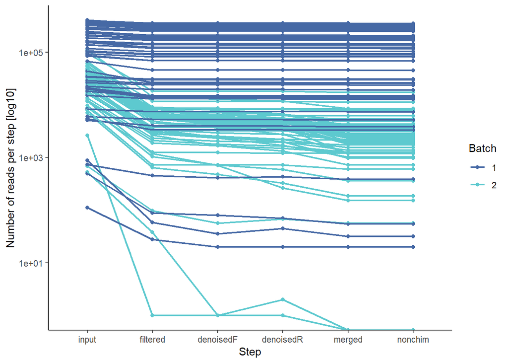

```r
# Loss in number of reads through the DADA2 pipeline by batch
track %>%
  rownames_to_column("Sample_ID") %>%
  pivot_longer(input:nonchim, names_to = "Step",
               values_to = "Number_of_reads") %>%
  mutate(Step = factor(Step, levels = colnames(track))) %>%
  merge(., metadata, by.x = "Sample_ID", by.y = "sample_id", all.x = TRUE) %>%
  ggplot(aes(x = Step, y = Number_of_reads, group = Sample_ID,
             colour = Batch)) +
  geom_point() +
  geom_line(size = 0.8) +
  scale_y_log10() + ylab("Number of reads per step [log10]") +
  theme_classic() +
  scale_colour_manual(values = theme_colours[c(1, 3)])
```

```r
# Mean percentage of recovered reads per step
track %>%
  filter(row.names(.) %in% metadata[metadata$Batch == "1", "sample_id"]) %>%
  mutate(./input) %>%
  summarise_all(mean)
```

```
##   input  filtered denoisedF denoisedR    merged  nonchim
## 1     1 0.8170878 0.8134791  0.813482 0.8086461 0.797272
```

```r
track %>%
  filter(row.names(.) %in% metadata[metadata$Batch == "2", "sample_id"]) %>%
  mutate(./input) %>%
  summarise_all(mean)
```

```
##   input filtered denoisedF denoisedR    merged    nonchim
## 1     1 0.153285 0.1328501 0.1193275 0.0924347 0.09238305
```

The second batch has slightly lower reads before denoising, but additionally loses a great proportion of reads during quality filtering (= has lower quality scores, as noted earlier). After denoising, second batch has roughly two orders of magnitude lower reads then the first batch, and by itself really low reads.  
The track table confirms that the first batch keeps 80% of sequences during denoising, and the second batch keeps only 9% of sequences on average. DADA2 filtering parameter maxEE could be increased a little to recover more reads, particularly in the second batch.

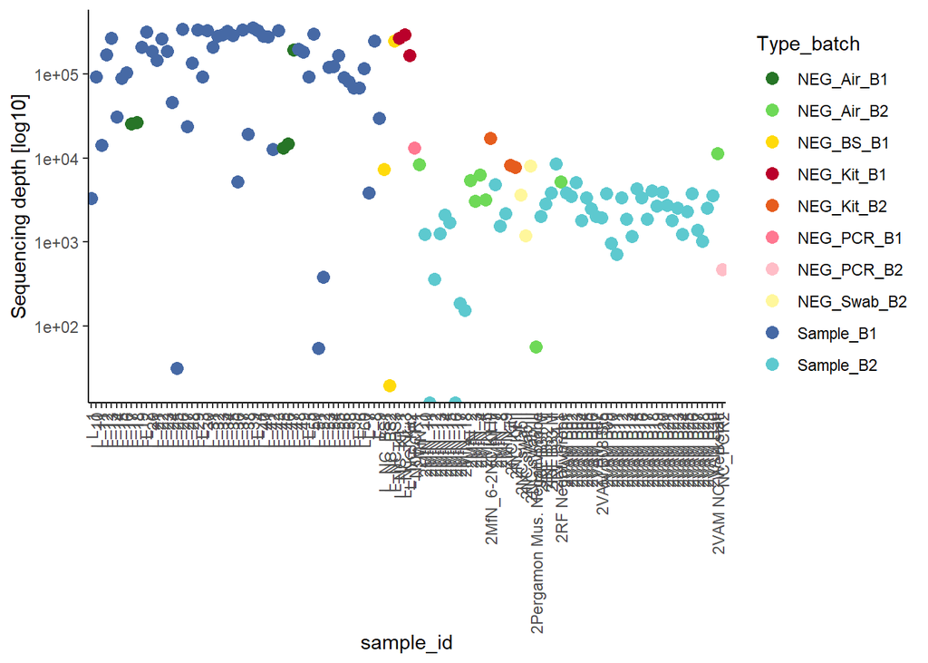

```r
# Different sequencing depths per batch
metadata["Seq_depth"] <- colSums(seqtab.final[, sample.names])
metadata %>%
  mutate(sample_id = factor(sample_id, levels = metadata$sample_id)) %>%
  ggplot(., aes(x = sample_id, y = Seq_depth, colour = Type_batch)) +
  geom_point(size = 3) +
  scale_y_log10() + ylab("Sequencing depth [log10]") +
  theme_classic() +
  scale_colour_manual(values = theme_colours[c(10, 6, 4, 5, 2, 11, 7, 9, 1, 3)]) +
  theme(axis.text.x = element_text(angle = 90, vjust = 0.5, hjust = 1))
```

First batch mostly has > 100,000 reads, second batch mostly has between 1,000 and 10,000 reads. As usually expected, PCR controls have lower reads than samples. Kit and swab negative controls (partially) have very high number of reads, so the data may require **contamination removal**.

### Sample composition

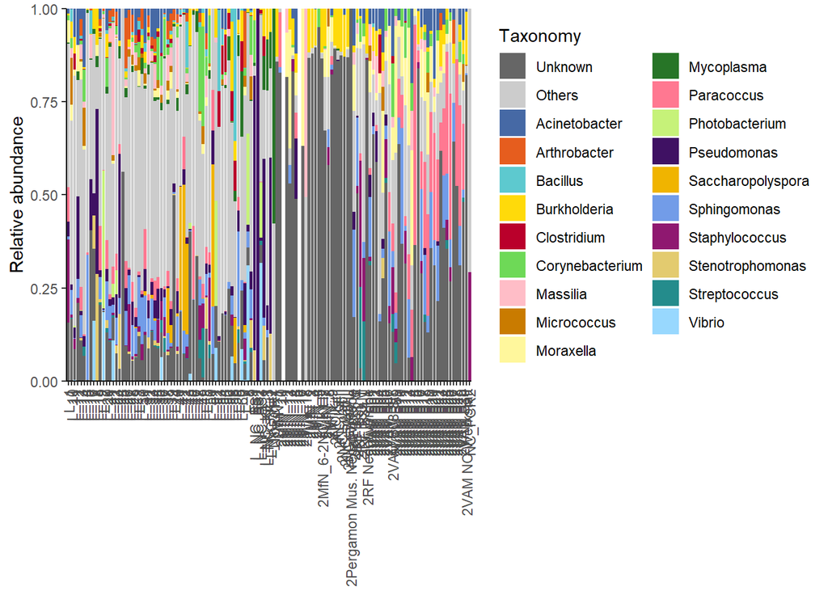

```r
# Function to generate plots of taxonomic sample composition
Taxonomy_plot <- function(seqtab_f, level, top_number, metafile, metavar){
  # Subset sample ids
  sample_ids <- sample.names[sample.names %in% colnames(seqtab_f)]
  # Scale to 100%
  seqtab_f[sample_ids] <- apply(seqtab_f[sample_ids], 2, function(x) {x/sum(x)})
  # Keep only selected taxonomic level
  seqtab_f <- seqtab_f[, c(sample_ids, level)]
  # Replace missing annotation
  seqtab_f[, level][is.na(seqtab_f[, level]) | seqtab_f[, level] == ""] <-
    "Unknown"
  # Sum up frequencies with identical taxonomy
  seqtab_f <- seqtab_f %>%
    group_by(.data[[level]]) %>%
    summarise(across(.cols = where(is.numeric), .fns = sum, .names = "{col}")) %>%
    as.data.frame()
  # Put taxonomic level as rownames
  rownames(seqtab_f) <- seqtab_f[, level]
  seqtab_f[, level] <- NULL
  seqtab_f <- as.data.frame(t(seqtab_f))
  # Merge with metainformation
  seqtab_f <- merge(seqtab_f, metafile[, colnames(metafile) == metavar, drop = F],
                    by = 0, all = F)
  seqtab_f[[metavar]] <- as.character(seqtab_f[[metavar]])
  # Build mean frequency per selected group
  seqtab_f <- seqtab_f %>%
    group_by(.data[[metavar]]) %>%
    summarise(across(.cols = where(is.numeric), .fns = function(x)
      {mean(x, na.rm = T)}, .names = "{col}")) %>%
    as.data.frame()
  seqtab_f[[metavar]][is.na(seqtab_f[[metavar]])] <- "missing"
  # Select top taxa per group or overall
  top_taxa <- seqtab_f %>%
    select_if(is.numeric) %>%
    colMeans(., na.rm = T) %>%
    sort(decreasing = TRUE)
  top_taxa <- names(top_taxa[1:top_number])
  # Summarise other taxa into "Others"
  top_taxa <- sort(top_taxa)
  taxonomy_others <- seqtab_f %>%
    select_if(is.numeric) %>%
    select(-all_of(top_taxa)) %>%
    rowSums() %>%
    data.frame
  colnames(taxonomy_others) <- "Others"
  # Merge taxonomy with others
  seqtab_f <- merge(
    taxonomy_others,
    seqtab_f[, c(top_taxa, metavar)], by = 0, all = TRUE)
  seqtab_f["Row.names"] <- NULL
  # Plot the result
  seqtab_f <- pivot_longer(
    seqtab_f, 1:(top_number+1),
    names_to = "Taxonomy",
    values_to = "Abundance")
  taxonomy_plot <- ggplot() +
    geom_bar(data = seqtab_f,
             aes(x = !!sym(metavar), y = !!sym("Abundance"), fill = Taxonomy),
             position = "fill", stat = "identity") +
    scale_fill_manual(values = setNames(c("grey40", "grey80", theme_colours[1:length(top_taxa)]),
                                        c("Unknown", "Others", top_taxa))) +
    ylab("Relative abundance") +
    theme_classic() +
    theme(axis.text.x = element_text(angle = 90, vjust = 0.5, hjust = 1)) +
    scale_y_continuous(expand = c(0, 0))
  return(list(seqtab_f, taxonomy_plot))
}

# Run taxonomy function for all samples
Tax_all <- Taxonomy_plot(seqtab.final, "Mixed_genus", 20, metadata,
                         "sample_id")
Tax_all[[2]] +
  scale_x_discrete(limits = metadata$sample_id) +
  theme(axis.title.x = element_blank())
```

Apart from differences in sequencing depths, there are visible differences in sample composition between the two batches, particularly in the proportion of unknown genera - thus, analyses should be **separated by batches**.  
This batch effect confirms that we cannot simply combine this data with publically available skin microbiome data.

Ideas to overcome batch effect:

- Downsampling / rarefaction of microbiome data to align sequencing depths per batch?
- Proof that data can be combined by using several replicates of two types of positive controls per batch, to show that samples cluster by original sample composition, and not by batch (but this requires new data collection/resequencing).

### Touch signature in taxonomic composition of the first batch

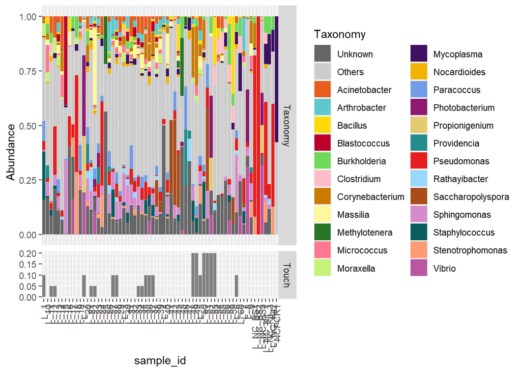

```r
Tax_batch1 <- Taxonomy_plot(seqtab.final, "Mixed_genus", 25,
                        metadata[metadata$Batch == "1", ], "sample_id")
# Add "fake" taxonomy data for touched objects
Touched_data <- data.frame(sample_id = metadata$sample_id,
                           Taxonomy = "Touched",
                           Abundance = case_when(
                             metadata$Touched == "xx" ~ 0.2,
                             metadata$Touched == "x" ~ 0.1,
                             metadata$Touched == "(x)" ~ 0.05,
                             TRUE ~ 0),
                           fake_var = "Touch")
# Merge taxonomy and touch data
Tax_batch1[[1]] %>%
  mutate(fake_var = "Taxonomy") %>%
  rbind.data.frame(
    ., Touched_data[Touched_data$sample_id %in% metadata[metadata$Batch == "1", "sample_id"], ]) %>%
  ggplot(., aes(x = sample_id, y = Abundance, fill = Taxonomy)) +
  geom_bar(position = "stack", stat = "identity") +
  facet_grid(fake_var ~ ., #ncol = 1,
             scales = "free_y", space = "free") +
  scale_fill_manual(values = setNames(
    c("grey40", "grey80", theme_colours[1:length(unique(Tax_batch1[[1]]$Taxonomy))]),
    c("Unknown", "Others", unique(Tax_batch1[[1]]$Taxonomy)))) +
  theme(axis.text.x = element_text(angle = 90, vjust = 0.5, hjust = 1))
```

Even without differential abundance analysis, we can see common skin inhabitants in the touched samples (e.g. Staphylococcus, Corynebacterium), but also in all samples (e.g. Acinetobacter, Sphingomonas), or even only in “untouched” samples (e.g. Moraxella, Micrococcus).  
Negative controls contain genera that have been found previously in negative controls, and that are rather not skin-associated (e.g. Burkholderia, Stenotrophomonas, Pseudomonas (the latter is also skin-associated)).

### PCA of touched objects

PCA on clr-transformed data:

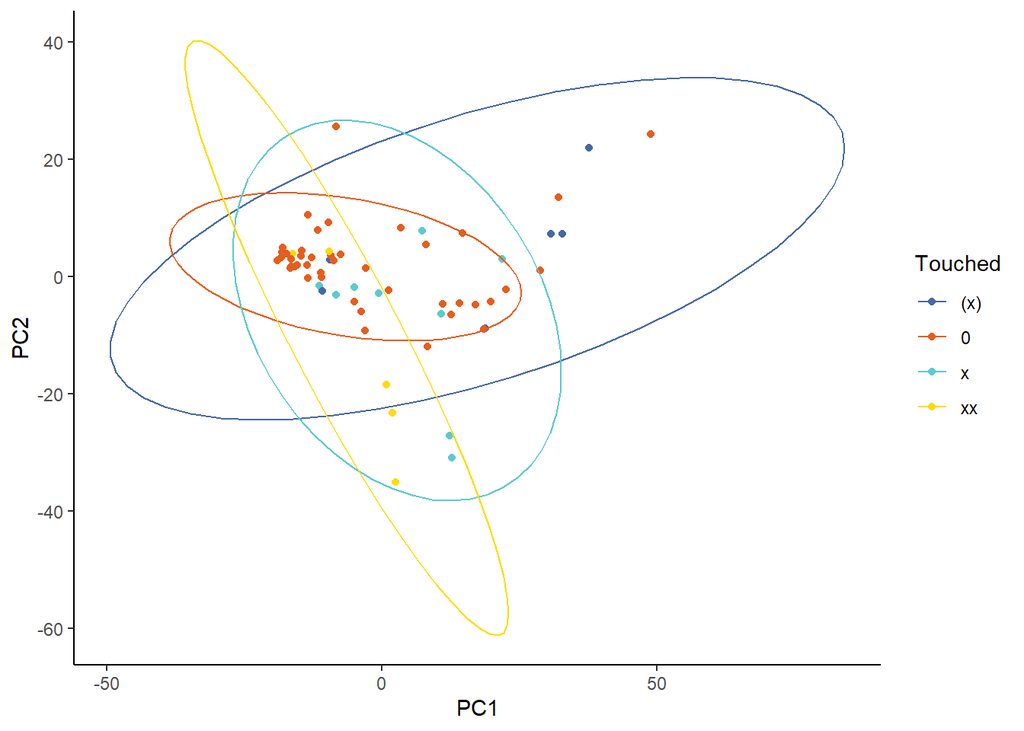

```r
# Define sample IDs for first batch
sample.names1 <- sample.names[sample.names %in%
                                metadata[metadata$Batch == "1", "sample_id"]]
# Subset samples from first batch
seqtab.final1 <- seqtab.final
seqtab.final1[metadata[metadata$Batch == "2", "sample_id"]] <- NULL
#seqtab.final2 <- seqtab.final2[, metadata[metadata$Batch == "1", "sample_id"]]
# Remove empty ASVs
seqtab.final1 <- seqtab.final1[rowSums(seqtab.final1[, sample.names1]) > 0, ]
#seqtab.final2 <- seqtab.final2[rowSums(seqtab.final2) > 0, ]
# Summarise at genus level
seqtab.final1 <- seqtab.final1 %>%
  group_by(Genus, Family, Order, Class, Phylum, Kingdom) %>%
  summarise_at(.vars = sample.names1, .funs = sum) %>%
  as.data.frame()
# Replace zeros by 0.5
seqtab.final1[seqtab.final1 == 0] <- 0.5
# CLR transformation
seqtab.final1_clr <- seqtab.final1
seqtab.final1_clr <- apply(seqtab.final1_clr[, sample.names1], 2, clr)

# PCA
pca_res1 <- prcomp(t(seqtab.final1_clr[, sample.names1]))
pca_data <- data.frame(pca_res1$x,
                       metadata[metadata$sample_id %in% sample.names1, ])

# Touched vs. untouched in all objects
ggplot(pca_data,
       aes(x = PC1, y = PC2)) +
  geom_point(aes(colour = Touched)) +
  stat_ellipse(aes(colour = Touched)) +
  scale_colour_manual(values = theme_colours) +
  theme_classic()
```

No generally clear separation between touched and untouched objects across all materials and objects.

```
## Too few points to calculate an ellipse
```

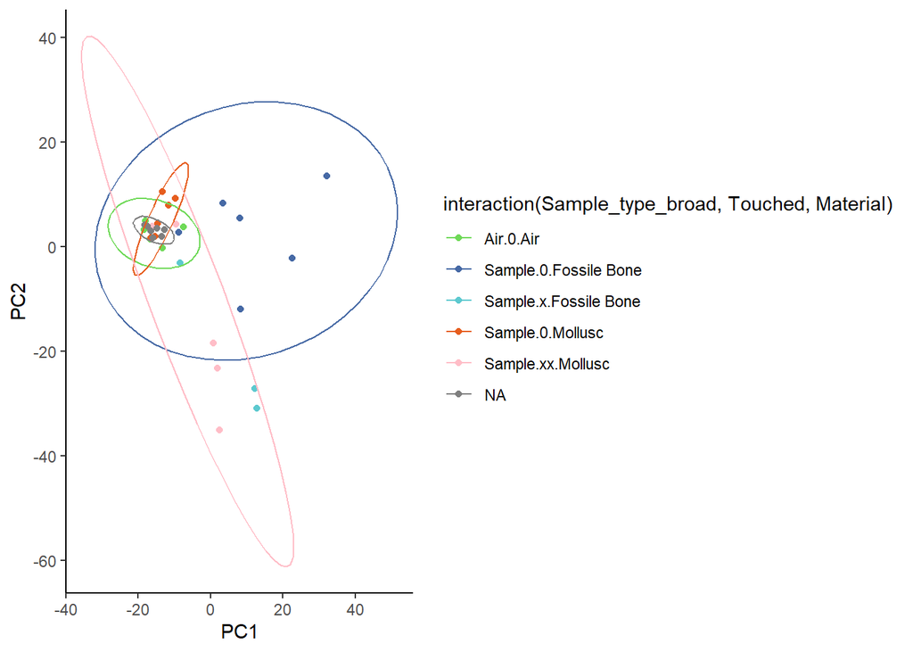

```r
# Replicate of touched vs. untouched in Tendaguru & Mollusc samples
ggplot(filter(pca_data, Object == "Tendaguru" | Material == "Mollusc" |
              grepl("NEG", Sample_type)),
       aes(x = PC1, y = PC2)) +
  geom_point(aes(colour = interaction(Sample_type_broad, Touched, Material))) +
  stat_ellipse(aes(colour = interaction(Sample_type_broad, Touched, Material))) +
  theme_classic() +
  scale_colour_manual(values = theme_colours[c(6, 1, 3, 2, 7)])
```

`NA`s represent negative controls here. In this subset, negative controls cluster together with air controls and the untouched mollusc samples; the untouched fossile bone is slightly different from the other untouched samples, but touched bone and touched mollusc cluster nicely together.